# report 7

Tara Boroushaki 93105501

4/26/2018

**1.** First, we should combine 2 methodes of education evaluation and multiple ways of defining age to one method. I converted 1998 version of education evaluation to 2003 version, and mutated a new column “Education”. AgeRecode27 is used for age since we do not need too much details on age of victims. CauseRecode39 was used for death cause, again because too much information can cause problem and too little information is not enough. Correlation matrix and scatter plots are as follows.

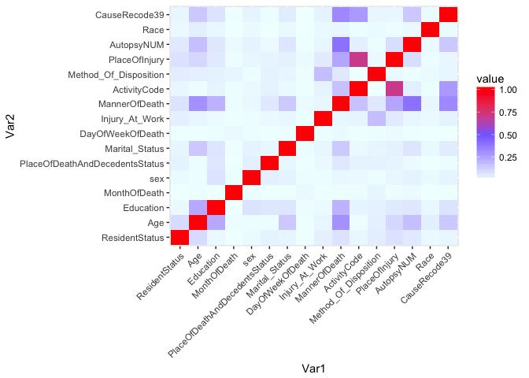

```r
death$Education=death$Education2003Revision
version1998=which(death$EducationReportingFlag==0)
for (i in version1998){
  if(death$Education1989Revision[i]<9)
    {death$Education[i]=1}
  if(death$Education1989Revision[i]>8 && death$Education1989Revision[i]<12)
    {death$Education[i]=2}
  if(death$Education1989Revision[i]==12)
    {death$Education[i]=3}
  if(death$Education1989Revision[i]==13 || death$Education1989Revision[i]==14)
    {death$Education[i]=4}
  if(death$Education1989Revision[i]==15)
    {death$Education[i]=5}
  if(death$Education1989Revision[i]==16)
    {death$Education[i]=6}
  if(death$Education1989Revision[i]==17)
    {death$Education[i]=7}
  if(death$Education1989Revision[i]==99)
    {death$Education[i]=9}
}
death$Education[which(death$Education==8)]=7

death %>% select(ResidentStatus,Age=AgeRecode27,Education,MonthOfDeath,Sex,
                 PlaceOfDeathAndDecedentsStatus,MaritalStatus,DayOfWeekOfDeath,
                 InjuryAtWork,MannerOfDeath,ActivityCode,MethodOfDisposition,
                 PlaceOfInjury,Autopsy,Race,CauseRecode39) ->CleanDeathData

CleanDeathData%>%mutate(Marital_Status=as.numeric(MaritalStatus),Injury_At_Work=as.numeric(InjuryAtWork),
                        AutopsyNUM=as.numeric(Autopsy),Method_Of_Disposition=as.numeric(MethodOfDisposition)
                        ,sex=as.numeric(Sex))%>% select(ResidentStatus,Age,Education,MonthOfDeath,sex,
                                         PlaceOfDeathAndDecedentsStatus,Marital_Status,DayOfWeekOfDeath,
                                         Injury_At_Work,MannerOfDeath,ActivityCode,Method_Of_Disposition,
                                         PlaceOfInjury,AutopsyNUM,Race,CauseRecode39)->CleanDeathData
CleanDeathData$MannerOfDeath=CleanDeathData$MannerOfDeath-2
corr_ = rcorr(as.matrix(CleanDeathData))
corr_matrix = corr_[[1]]
pvalue_matrix = corr_[[3]]
  #matrix
melted_cormat <- melt(abs(corr_matrix))
ggplot(data = melted_cormat, aes(x=Var1, y=Var2, fill=value)) +
  geom_tile() +
  theme(axis.text.x = element_text(angle = 45, hjust = 1, vjust = 1))+
  scale_fill_gradientn(colours = c("azure","slateblue1","red"), values = c(0,0.5,1))
```

[figure not shown]

```r
  #scatter plots
plots = list()
vars = colnames(CleanDeathData)
for (i in 2:16){
  for(j in 1:(i-1)){
    p = ggplot(data = CleanDeathData,aes(x=CleanDeathData %>% select(vars[i]), y=CleanDeathData %>% select(vars[j])))+
      ylab(vars[j])+xlab(vars[i])+geom_point(aes(size = CleanDeathData %>% select(vars[i]))) +
      theme(legend.position = "none") +
      geom_smooth(method="lm", formula=y~x, colour = "blue")
    plots = list.append(plots,p)
  }
}

do.call(grid.arrange,c(plots[1:16],ncol = 4))
```

[figure not shown]

```r
do.call(grid.arrange,c(plots[17:32],ncol = 4))
```

[figure not shown]

```r
do.call(grid.arrange,c(plots[33:48],ncol = 4))
```

[figure not shown]

```r
do.call(grid.arrange,c(plots[49:64],ncol = 4))
```

[figure not shown]

```r
do.call(grid.arrange,c(plots[65:80],ncol = 4))
```

[figure not shown]

```r
do.call(grid.arrange,c(plots[81:96],ncol = 4))
```

[figure not shown]

```r
do.call(grid.arrange,c(plots[97:112],ncol = 4))
```

[figure not shown]

```r
do.call(grid.arrange,c(plots[113:120],ncol = 4))
```

**2.** Correlation test between each of mentioned columns with Manner of Death is computed. Education level and Age have the highest correlations, therefore have more influence on the result.

```r
Q2Data=CleanDeathData%>%select(sex,Race,Education,Age,Method_Of_Disposition,MannerOfDeath)

Q2Data %>%  ggplot( aes(x = MannerOfDeath, y =.[,1])) + geom_point()+geom_jitter(width = 0.1, height = 0.1)+
  geom_smooth(method="lm", formula=y~x, colour = "blue")+
  ylab(names(Q2Data)[1])+xlab("Price")->p2_1
cor.test(Q2Data$sex,Q2Data$MannerOfDeath)
```

```
##
##  Pearson's product-moment correlation
##
## data:  Q2Data$sex and Q2Data$MannerOfDeath
## t = 4.9153, df = 59977, p-value = 8.888e-07
## alternative hypothesis: true correlation is not equal to 0
## 95 percent confidence interval:
##  0.01206539 0.02806484
## sample estimates:
##       cor
## 0.0200664
```

```r
Q2Data %>%  ggplot( aes(x = MannerOfDeath, y =.[,2])) + geom_point()+geom_jitter(width = 0.1, height = 0.1)+
  geom_smooth(method="lm", formula=y~x, colour = "blue")+
  ylab(names(Q2Data)[2])+xlab("Price")->p2_2
cor.test(Q2Data$Race,Q2Data$MannerOfDeath)
```

```
##
##  Pearson's product-moment correlation
##
## data:  Q2Data$Race and Q2Data$MannerOfDeath
## t = 5.1604, df = 59977, p-value = 2.472e-07
## alternative hypothesis: true correlation is not equal to 0
## 95 percent confidence interval:
##  0.01306592 0.02906472
## sample estimates:
##        cor
## 0.02106667
```

```r
Q2Data %>%  ggplot( aes(x = MannerOfDeath, y =.[,3])) + geom_point()+geom_jitter(width = 0.1, height = 0.1)+
  geom_smooth(method="lm", formula=y~x, colour = "blue")+
  ylab(names(Q2Data)[3])+xlab("Price")->p2_3
cor.test(Q2Data$Education,Q2Data$MannerOfDeath)
```

```
##
##  Pearson's product-moment correlation
##
## data:  Q2Data$Education and Q2Data$MannerOfDeath
## t = -51.575, df = 59977, p-value < 2.2e-16
## alternative hypothesis: true correlation is not equal to 0
## 95 percent confidence interval:
##  -0.2137266 -0.1984003
## sample estimates:
##        cor
## -0.2060761
```

```r
Q2Data %>%  ggplot( aes(x = MannerOfDeath, y =.[,4])) + geom_point()+geom_jitter(width = 0.1, height = 0.1)+
  geom_smooth(method="lm", formula=y~x, colour = "blue")+
  ylab(names(Q2Data)[4])+xlab("Price")->p2_4
cor.test(Q2Data$Age,Q2Data$MannerOfDeath)
```

```
##
##  Pearson's product-moment correlation
##
## data:  Q2Data$Age and Q2Data$MannerOfDeath
## t = -78.685, df = 59977, p-value < 2.2e-16
## alternative hypothesis: true correlation is not equal to 0
## 95 percent confidence interval:
##  -0.3131279 -0.2986195
## sample estimates:
##        cor
## -0.3058915
```

```r
Q2Data %>%  ggplot( aes(x = MannerOfDeath, y =.[,5])) + geom_point()+geom_jitter(width = 0.1, height = 0.1)+
  geom_smooth(method="lm", formula=y~x, colour = "blue")+
  ylab(names(Q2Data)[5])+xlab("Price")->p2_5
cor.test(Q2Data$Method_Of_Disposition,Q2Data$MannerOfDeath)
```

```
##
##  Pearson's product-moment correlation
##
## data:  Q2Data$Method_Of_Disposition and Q2Data$MannerOfDeath
## t = -15.247, df = 59977, p-value < 2.2e-16
## alternative hypothesis: true correlation is not equal to 0
## 95 percent confidence interval:
##  -0.07010381 -0.05415970
## sample estimates:
##         cor
## -0.06213572
```

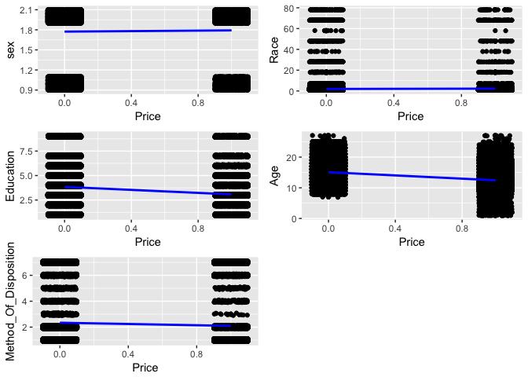

```r
grid.arrange(p2_1, p2_2, p2_3, p2_4,p2_5)
```

**3.** Three different model are trained. “mylogit3” is selected as the best since all the inputs get ***, which shows they influence the result.

```r
# Q3


mylogit = glm(MannerOfDeath ~ Education + AutopsyNUM + CauseRecode39 + PlaceOfInjury,
              data = CleanDeathData, family = "binomial"(link = 'logit'))
summary(mylogit)
```

```
##
## Call:
## glm(formula = MannerOfDeath ~ Education + AutopsyNUM + CauseRecode39 +
##     PlaceOfInjury, family = binomial(link = "logit"), data = CleanDeathData)
##
## Deviance Residuals:
##     Min       1Q   Median       3Q      Max
## -5.7667  -0.4366  -0.1358   0.3949   8.4904
##
## Coefficients:
##                 Estimate Std. Error z value Pr(>|z|)
## (Intercept)   -1.548e+02  1.237e+00 -125.14   <2e-16 ***
## Education     -1.894e-01  9.364e-03  -20.22   <2e-16 ***
## AutopsyNUM     1.284e+00  3.457e-02   37.13   <2e-16 ***
## CauseRecode39  3.729e+00  3.061e-02  121.83   <2e-16 ***
## PlaceOfInjury  1.120e-01  1.565e-03   71.60   <2e-16 ***
## ---
## Signif. codes:  0 '***' 0.001 '**' 0.01 '*' 0.05 '.' 0.1 ' ' 1
##
## (Dispersion parameter for binomial family taken to be 1)
##
##     Null deviance: 71216  on 59978  degrees of freedom
## Residual deviance: 23226  on 59974  degrees of freedom
## AIC: 23236
##
## Number of Fisher Scoring iterations: 8
```

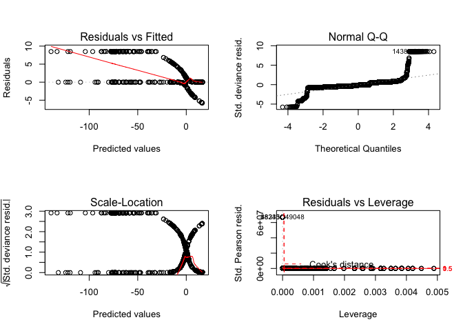

```r
par(mfrow=c(2,2))
plot(mylogit)
```

```r
mylogit2 = glm(MannerOfDeath ~ sex + Race + Method_Of_Disposition + Education + Age +
                 AutopsyNUM + CauseRecode39 + PlaceOfInjury,
              data = CleanDeathData, family = "binomial"(link = 'logit'))
summary(mylogit2)
```

```
##
## Call:
## glm(formula = MannerOfDeath ~ sex + Race + Method_Of_Disposition +
##     Education + Age + AutopsyNUM + CauseRecode39 + PlaceOfInjury,
##     family = binomial(link = "logit"), data = CleanDeathData)
##
## Deviance Residuals:
##     Min       1Q   Median       3Q      Max
## -5.7091  -0.4017  -0.1430   0.3642   8.4904
##
## Coefficients:
##                         Estimate Std. Error  z value Pr(>|z|)
## (Intercept)           -1.488e+02  1.255e+00 -118.502  < 2e-16 ***
## sex                   -1.143e-01  3.574e-02   -3.198  0.00138 **
## Race                   1.640e-03  2.207e-03    0.743  0.45739
## Method_Of_Disposition -4.964e-02  8.409e-03   -5.903 3.58e-09 ***
## Education             -1.533e-01  9.717e-03  -15.780  < 2e-16 ***
## Age                   -8.524e-02  4.362e-03  -19.543  < 2e-16 ***
## AutopsyNUM             1.273e+00  3.477e-02   36.625  < 2e-16 ***
## CauseRecode39          3.616e+00  3.096e-02  116.794  < 2e-16 ***
## PlaceOfInjury          1.084e-01  1.574e-03   68.880  < 2e-16 ***
## ---
## Signif. codes:  0 '***' 0.001 '**' 0.01 '*' 0.05 '.' 0.1 ' ' 1
##
## (Dispersion parameter for binomial family taken to be 1)
##
##     Null deviance: 71216  on 59978  degrees of freedom
## Residual deviance: 23181  on 59970  degrees of freedom
## AIC: 23199
##
## Number of Fisher Scoring iterations: 8
```

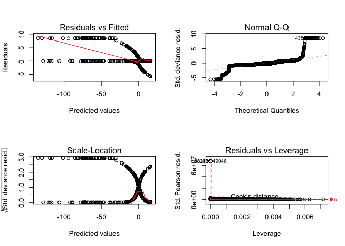

```r
par(mfrow=c(2,2))
plot(mylogit2)
```

```r
mylogit3 = glm(MannerOfDeath ~ Method_Of_Disposition + Education + Age +
                 AutopsyNUM + CauseRecode39 + PlaceOfInjury,
               data = CleanDeathData, family = "binomial"(link = 'logit'))
summary(mylogit3)
```

```
##
## Call:
## glm(formula = MannerOfDeath ~ Method_Of_Disposition + Education +
##     Age + AutopsyNUM + CauseRecode39 + PlaceOfInjury, family = binomial(link = "logit"),
##     data = CleanDeathData)
##
## Deviance Residuals:
##     Min       1Q   Median       3Q      Max
## -5.7106  -0.3978  -0.1441   0.3665   8.4904
##
## Coefficients:
##                         Estimate Std. Error  z value Pr(>|z|)
## (Intercept)           -1.489e+02  1.256e+00 -118.562  < 2e-16 ***
## Method_Of_Disposition -4.954e-02  8.406e-03   -5.894 3.78e-09 ***
## Education             -1.509e-01  9.681e-03  -15.587  < 2e-16 ***
## Age                   -8.468e-02  4.343e-03  -19.497  < 2e-16 ***
## AutopsyNUM             1.274e+00  3.474e-02   36.678  < 2e-16 ***
## CauseRecode39          3.614e+00  3.095e-02  116.745  < 2e-16 ***
## PlaceOfInjury          1.083e-01  1.571e-03   68.945  < 2e-16 ***
## ---
## Signif. codes:  0 '***' 0.001 '**' 0.01 '*' 0.05 '.' 0.1 ' ' 1
##
## (Dispersion parameter for binomial family taken to be 1)
##
##     Null deviance: 71216  on 59978  degrees of freedom
## Residual deviance: 23200  on 59972  degrees of freedom
## AIC: 23214
##
## Number of Fisher Scoring iterations: 8
```

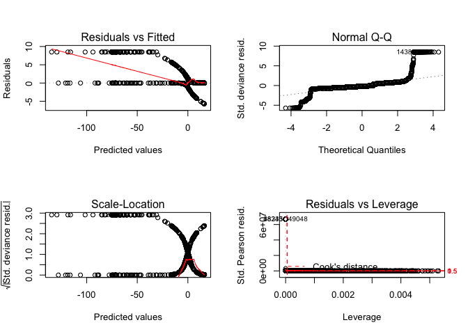

```r
par(mfrow=c(2,2))
plot(mylogit3)
```

**4.**

Using “ROCInfo” we can identify the best possible thereshold. Since the question the police face is whether it was murder or suicide, not whether someone is guilty or innocence, I chosed cost.fp and cost.fn equal. I believe plots show that accuracy is okay.

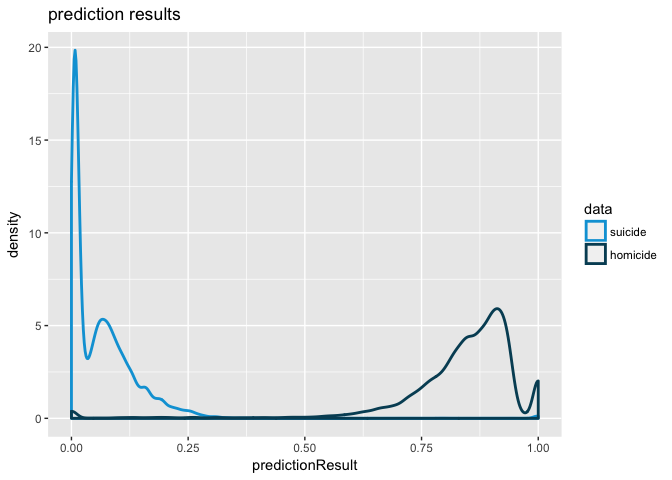

```r
# Q4

CleanDeathData$predictionResult=predict(mylogit3,  newdata = CleanDeathData, type = 'response')
  #1
ggplot( CleanDeathData, aes( predictionResult, color = as.factor(MannerOfDeath))) +
  geom_density( size = 1 ) + ggtitle( "prediction results" )  +
  scale_color_economist( name = "data", labels = c( "suicide", "homicide" ) )
```

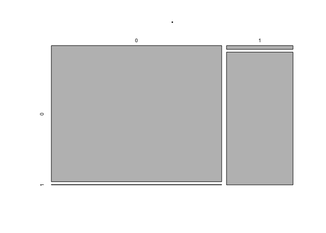

```r
  #2
table(CleanDeathData$MannerOfDeath,ifelse(fitted(mylogit3)>0.5,1,0)) %>% plot()
```

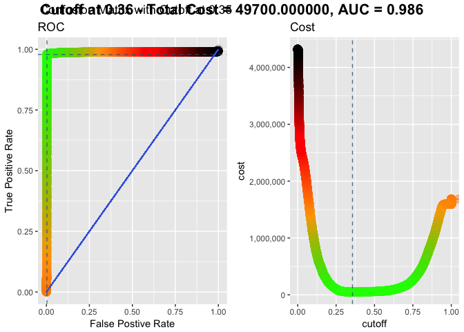

```r
  #3
cm_info = ConfusionMatrixInfo( data = CleanDeathData, predict = "predictionResult",
                               actual = "MannerOfDeath", cutoff = .35 )
cm_info$plot
TPR = sum(cm_info$data$type == "TP")/sum(CleanDeathData$MannerOfDeath ==1)
FPR = sum(cm_info$data$type == "FP")/sum(CleanDeathData$MannerOfDeath ==0)

cost_fp = 100;cost_fn = 100
roc_info = ROCInfo( data = cm_info$data, predict = "predict",
                    actual = "actual", cost.fp = cost_fp, cost.fn = cost_fn )
grid.draw(roc_info$plot)
```

**5.** Using “Sample”, we extract test and train random indices.

```r
# Q5

  # extracting test and train random indices
num = nrow(CleanDeathData)
train_nrows = sample(1:num,size = 0.8*num, replace = F)
test_nrows = c(1:num)[-train_nrows]

Train=CleanDeathData[train_nrows,1:16]
Test=CleanDeathData[test_nrows,1:16]

trainLogMod=glm(MannerOfDeath ~ Method_Of_Disposition + Education + Age +
                  AutopsyNUM + CauseRecode39 + PlaceOfInjury,
                data = Train, family = "binomial"(link = 'logit'))
```

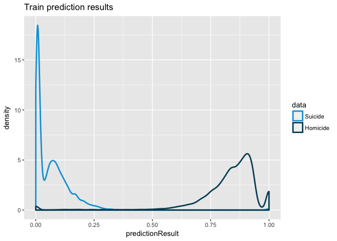

```r
Train$predictionResult = predict(trainLogMod,  newdata = Train, type = 'response')
Test$predictionResult = predict(trainLogMod,  newdata = Test, type = 'response')

ggplot( Train, aes( predictionResult, color = as.factor(MannerOfDeath))) +
  geom_density( size = 1 ) +
  ggtitle( "Train prediction results" ) +
  scale_color_economist( name = "data", labels = c( "Suicide", "Homicide" ) )
```

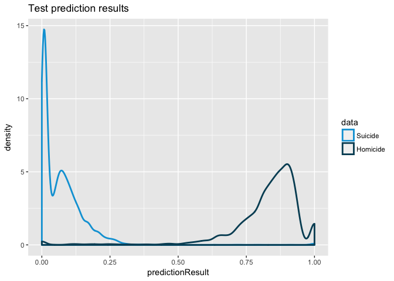

```r
ggplot( Test, aes( predictionResult, color = as.factor(MannerOfDeath))) +
  geom_density( size = 1 ) +
  ggtitle( "Test prediction results" ) +
  scale_color_economist( name = "data", labels = c( "Suicide", "Homicide" ) )
```

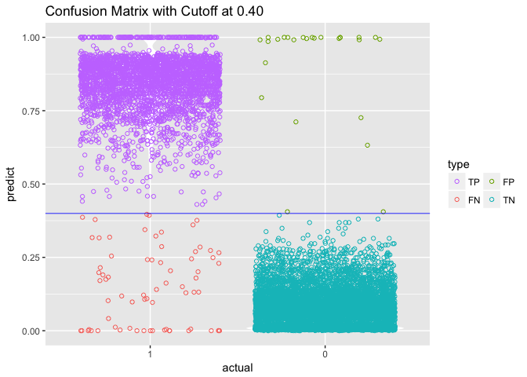

```r
cm_info5 = ConfusionMatrixInfo( data = Test, predict = "predictionResult",
                               actual = "MannerOfDeath", cutoff = .4)
cm_info5$plot
```

```r
results5 = cm_info5$data$type
P = sum(results5 == "FN" | results5 == "TP")
N = sum(results5 == "FP" | results5 == "TN")
TP = sum(results5 == "TP")
TN = sum(results5 == "TN")
FP = sum(results5 == "FP")
FN = sum(results5 == "FN")
ACC = (TP+TN)/(P+N)
TPR = TP/P
FPR = FP/N

writeLines(as.character(cat("Positive lable =",P))
                       ,con = stdout(), sep = "\n", useBytes = FALSE)
```

```
## Positive lable = 3398
```

```r
writeLines(as.character(cat("Negative lable =",N))
           ,con = stdout(), sep = "\n", useBytes = FALSE)
```

```
## Negative lable = 8598
```

```r
writeLines(as.character(cat("True Positive prediction =",TP))
           ,con = stdout(), sep = "\n", useBytes = FALSE)
```

```
## True Positive prediction = 3322
```

```r
writeLines(as.character(cat("True Negative prediction =",TN))
           ,con = stdout(), sep = "\n", useBytes = FALSE)
```

```
## True Negative prediction = 8572
```

```r
writeLines(as.character(cat("False Positive prediction =",FP))
           ,con = stdout(), sep = "\n", useBytes = FALSE)
```

```
## False Positive prediction = 26
```

```r
writeLines(as.character(cat("False Negative prediction =",FN))
           ,con = stdout(), sep = "\n", useBytes = FALSE)
```

```
## False Negative prediction = 76
```

```r
writeLines(as.character(cat("Accuracy =",ACC))
           ,con = stdout(), sep = "\n", useBytes = FALSE)
```

```
## Accuracy = 0.9914972
```

```r
writeLines(as.character(cat("True positive rate =",TPR))
           ,con = stdout(), sep = "\n", useBytes = FALSE)
```

```
## True positive rate = 0.9776339
```

```r
writeLines(as.character(cat("False positive rate =",FPR))
           ,con = stdout(), sep = "\n", useBytes = FALSE)
```

```
## False positive rate = 0.003023959
```

**6.**

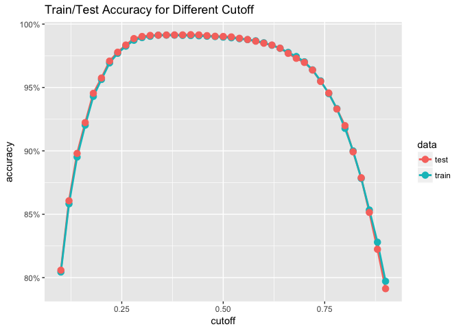

```r
# Q6
accuracy_info = AccuracyCutoffInfo( train = Train, test = Test,
                                    predict = "predictionResult", actual = "MannerOfDeath" )
accuracy_info$plot
```

```r
accuracy_info$data$cutoff[which.max(accuracy_info$data$test)]
```

```
## [1] 0.42
```

**7.**

**Test Results:**

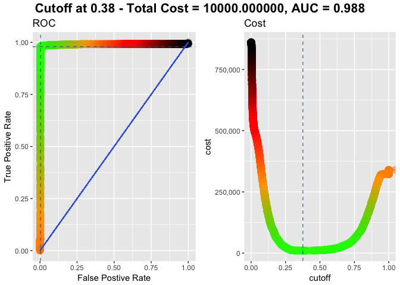

```r
# Q7

 # Test
roc_info5 = ROCInfo( data = cm_info5$data, predict = "predict",
                     actual = "actual", cost.fp = cost_fp, cost.fn = cost_fn )
grid.draw(roc_info5$plot)
```

**Train Results:**

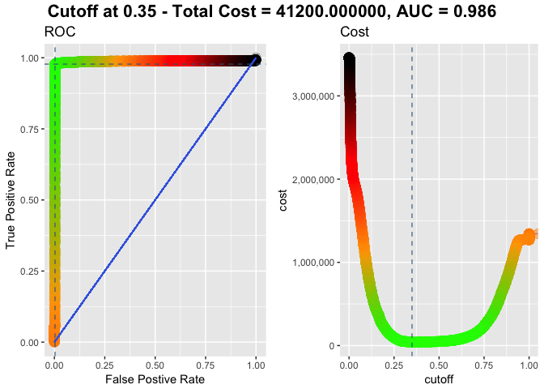

```r
 # Train

cm_info7 = ConfusionMatrixInfo( data = Train, predict = "predictionResult",
                                actual = "MannerOfDeath", cutoff = .4)
roc_info7 = ROCInfo( data = cm_info7$data, predict = "predict",
                     actual = "actual", cost.fp = cost_fp, cost.fn = cost_fn )
grid.draw(roc_info7$plot)
```

**8.**

TPR of this model (recall) doesn’t show a significant change when compared to previuos model. FPR of this model (1-specificity) doesn’t show a significant change when compared to previuos model.

```r
library(h2o)
h2o.init(nthreads = -1, max_mem_size = '2g', ip = "127.0.0.1", port = 50001)
```

[output not shown]

```r
hDeathData = as.h2o(CleanDeathData)
chglm = h2o.glm(y = "MannerOfDeath", x= colnames(hDeathData)[c(1:9,10:16)],
                training_frame = hDeathData, family="binomial",nfolds = 5)
chglm
```

```
## Model Details:
## ==============
##
## H2OBinomialModel: glm
## Model ID:  GLM_model_R_1524749549546_55
## GLM Model: summary
##     family  link                                regularization
## 1 binomial logit Elastic Net (alpha = 0.5, lambda = 3.604E-4 )
##   number_of_predictors_total number_of_active_predictors
## 1                         15                          15
##   number_of_iterations training_frame
## 1                    6 CleanDeathData
##
## Coefficients: glm coefficients
##                             names coefficients standardized_coefficients
## 1                       Intercept  -154.344069                 -1.742143
## 2                  ResidentStatus     0.048836                  0.026572
## 3                             Age    -0.078518                 -0.304535
## 4                       Education    -0.141343                 -0.236462
## 5                    MonthOfDeath     0.005205                  0.017639
## 6                             sex    -0.079683                 -0.033085
## 7  PlaceOfDeathAndDecedentsStatus    -0.090485                 -0.177215
## 8                  Marital_Status     0.140801                  0.139870
## 9                DayOfWeekOfDeath     0.009058                  0.018128
## 10                 Injury_At_Work     0.113672                  0.034997
## 11                   ActivityCode     0.167399                  2.062002
## 12          Method_Of_Disposition    -0.048728                 -0.086119
## 13                  PlaceOfInjury     0.102083                  1.537009
## 14                     AutopsyNUM     1.294294                  1.195451
## 15                           Race     0.001304                  0.008603
## 16                  CauseRecode39     3.705159                  4.371780
##
## H2OBinomialMetrics: glm
## ** Reported on training data. **
##
## MSE:  0.01961068
## RMSE:  0.1400381
## LogLoss:  0.1982452
## Mean Per-Class Error:  0.0112912
## AUC:  0.9887737
```

[output cut: 74 more lines]

```
## ---
##                         mean           sd cv_1_valid cv_2_valid cv_3_valid
## precision         0.98974615 0.0012069077 0.98733413  0.9896183 0.99236643
## r2                 0.9015613 0.0019347401 0.89941823 0.89929307  0.9061037
## recall             0.9812376 7.3632225E-4  0.9796529  0.9815264  0.9805628
## residual_deviance  5719.5923    352.57587   5697.163  5346.6084   6687.316
## rmse              0.14097066 0.0013595382 0.14282833 0.14176169 0.13806619
## specificity        0.9960295 4.8135803E-4  0.9950448 0.99608654 0.99701935
##                   cv_4_valid cv_5_valid
## precision          0.9906711 0.98874074
## r2                0.90337366 0.89961785
## recall             0.9826866 0.98175937
## residual_deviance   5393.322  5473.5513
## rmse              0.13937546 0.14282164
## specificity         0.996424  0.9955726
```

**9.**

لیبیل های داده های ورودی بر اساس تشخیص پلیس و دادستان تعیین شده اند که میتواند خطا داشته باشد و بعضی قتل ها را خودکشی و بعضی خودکشی ها را قتل تشخیص داده باشند. پس وقتی سیستمی را بر اساس این داده ها آموزش می دهیم، سپس پلیس و قاضی را از نتایج آن آگاه میکنیم، منطق و تصمیم گیری آن افراد را تحت تاثیر قرار میدهیم (لنگر ذهنی). حتی اگر خروجی این شبکه به عنوان دلیل قوی ای در سیستم قضایی جا نداشته باشد، به روند تصمیم گیری جهت میدهد. وقتی قاضی و پلیس، در مورد پرونده های جدید به کمک خروجی این شبکه تصمیم گیری میکنند و ما مثلا سالی یکبار مدل را با توجه به داده های جدید بهبود میدهیم، خطای شبکه رفته رفته افزایش میابد. چون خطا های شبکه ی قدیمی، به عنوان داده ی ترین شبکه ی نو استفاده می شود. رفته رفته خطا افزایش میابد و لوپ باطلی است. به علاوه از نظر اخلاقی هر پرونده باید مستقل بررسی شود و نه تحت تاثیر پرونده های قبلی. اگر از سیستم ای استفاده کنیم که بر اساس داده های پرونده های قبلی آموزش دیده، قانون نقض شده است. زیرا هر پرونده ویژگی های منحصر به فرد خود را دارد. نمیتوان همه ی اطلاعات را در ۳۰-۴۰ ستون دسته بندی کرد. در چنین موضوعاتی نمیتوان و نباید از چنین سرویسی استفاده کنیم.

لزوما هر پرونده ی تشخیص قتل یا خودکشی مظنونی ندارد. (بسیاری از پرونده های جنایی هیچ گاه مختومه نمی شوند و یا قاتل های بسیاری هرگز پیدا نمیشوند.) اگر بخواهیم از سرناچاری سیستمی برای کمک به قضات طراحی کنیم، زمانی که مظنونی برای پرونده وجود دارد باید pvalue را بسیار کوچک بگیریم. (چون فرض بیگناهی مظنون باید باشد) وقتی مظنونی وجود ندارد، میتوان pvalue را بزرگتر گرفت تا پلیس به دنبال شواهد بیشتری برای پیدا کردن قاتل احتمالی یا رد فرضیه ی رخدادن قتل بگردد.